# Introduction to Hypothesis Testing

Steve Elston

01/30/2021

# Overview of Hypothesis Testing

*“Critical tests of this kind may be called tests of significance, and when such tests are available we may discover whether a second sample is or is not significantly different from the first.”*

Ronald A. Fisher - 1925

- Basic hypothesis tests
- Types of hypothesis tests
- Steps in a test of hypothesis
- Multiple hypotheses and P-value fishing

# Introduction to Statistical Inference

All statistical inference has uncertainty

- Characterization of uncertainty is a goal of statistical inference
  - Any model using real-world data has inherent uncertainty
- Statistical inference seeks to avoid being [**fooled by randomness**](https://www.penguinrandomhouse.com/books/176225/fooled-by-randomness-by-nassim-nicholas-taleb/); A catchy title of a book
- A very few examples where proper statistical inference is important

| Hypothesis | Fooled by Randomness |
| --- | --- |
| How certain are you that eating fast food improves your health? | Some of my friends are doing great on this diet |
| How much confidence should we have that a marketing campaign increased sales? | Sales are up in the last month since the campaign started |
| How effective is a certain stock trading strategy for actually improving returns? | Traders using this strategy have made money recently |
| How good are the model parameter estimates? | The model has made accurate predictions so far |

# Applications of Statistical Inference

Confusingly, the term statistical inference is applied in many contexts

Some applications of statistical inference include:

**Inference on differences in distributions:** Are samples drawn from the same distribution or not? - A **null hypothesis** is the hypothesis that the distributions are the same

**Inference for model parameters and model selection:** Statistical models, including machine learning models, have unknown parameters for which the values must be estimated  
- Compute uncertainty in model parameter estimates  
- Compare model performance

**Inference for prediction:** In recent decades the distinction between prediction and classical inference has blurred to the point of being irrelevant  
- A common machine learning example, classification, uses decision rules determine the most likely class for each case of input values  
- inference also used to determine the confidence in predictions

# different kinds of tests

- we may have a different test if we have **one sample**, **two samples** or more
- a **parametric** test usually makes a set of assumptions about the distribution of the data, but if certain important assumptions don’t hold, we can look for a **non-parametric** tests
- which test to use also depends on whether the variable are **discrete or continuous**, or **numeric or categorical**, **ordinal, interval, or ratio**
- there are tests used for comparing **effect size** (averages), for comparing **variance**, for **goodness of fit** (proportions), for checking whether data follows a particular **distribution**, or if data points appear to be **independent** or not

# Sampling Distributions

Sampling of a population is done from an unknown **population distribution**, $\mathcal{F}$

- Any statistic we compute for the generating process is based on a sample, $\hat{\mathcal{F}}$
- The statistic is an approximation, $s(\hat{\mathcal{F}})$ of a **population parameter**
  - For example, the mean of the population is $\mu$
  - But, sample estiamte is $\bar{x}$
- If we continue to take random samples from the population and compute estimates of a statistic, we generate a **sampling distribution**
  - Hypothetical concept of the sampling distribution is a foundation of **frequentist statistics**
  - Example, if we continue generating samples and computing the sample means, $\bar{x}_i$ for the ith sample
- **Frequentist statistics** built on the idea of randomly resampling the population distribution and recomputing a statistic
  - In the frequentist world, statistical inferences are performed on the sampling distribution
  - Sampling process must not bias the estimates of the statistic

# Sampling Distributions

Sampling of a population is done from an unknown **population distribution**, $\mathcal{F}$

- Any statistic we compute for the generating process is an approximation for the population, $s(\hat{\mathcal{F}})$

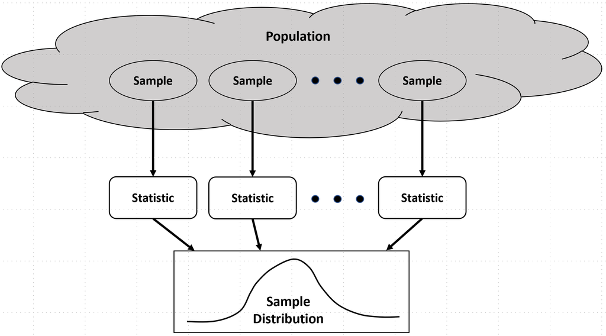

Sampling distribution of unknown population parameter

# Confidence Intervals; the Key to Inference

In frequentist statistics uncertainty of an inference is expressed in terms of a **confidence interval**

- A confidence interval is defined as the expected range of a statistical **point estimate**
  - A point estimate is the best statistical estimate of some value
  - For example, the most likely value of a model parameter given the data
- Two types of of confidence intervals:
  - **Two-sided confidence intervals:** express confidence that a value is within some range around the point estimate
  - **One-sided confidence intervals:** express confidence that the point estimate is greater or less than some range of values

# Confidence Intervals; the Key to Inference

Can understand confidence intervals by looking at the $\alpha$ and $1 - \alpha$ quantiles of a distribution

- Confidence interval corresponds to the span of the distribution between quantiles
- Express a 2-sided confidence interval for a random variable, $\mathbf{x}$, in terms of the probability as:

$$1-2 \alpha = P \Big( Lower\ CI \le \mathbf{x} \le Upper\ CI \Big)$$

- Alternatively for one-sided CIs:

$$\alpha = P(x \ge Upper\ CI)\ \\ and \\\ 1 - \alpha = P(x \le Lower\ CI)$$

# Example; confidence intervals of the Normal distribution

Illustrate the concept of confidence intervals with an example

- The **cumulative distribution function (CDF)** of a standard Normal distribution, $N(0,1)$
- Double ended arrows with annotation are plotted to illustrate the 95% confidence interval on the CDF
  - Horizontal double arrow shows the range of the confidence interval
  - Vertical double arrow shows the part of the distribution within the confidence intervals

```
## Confidence Interval, lower: -1.96, upper:  1.96
```

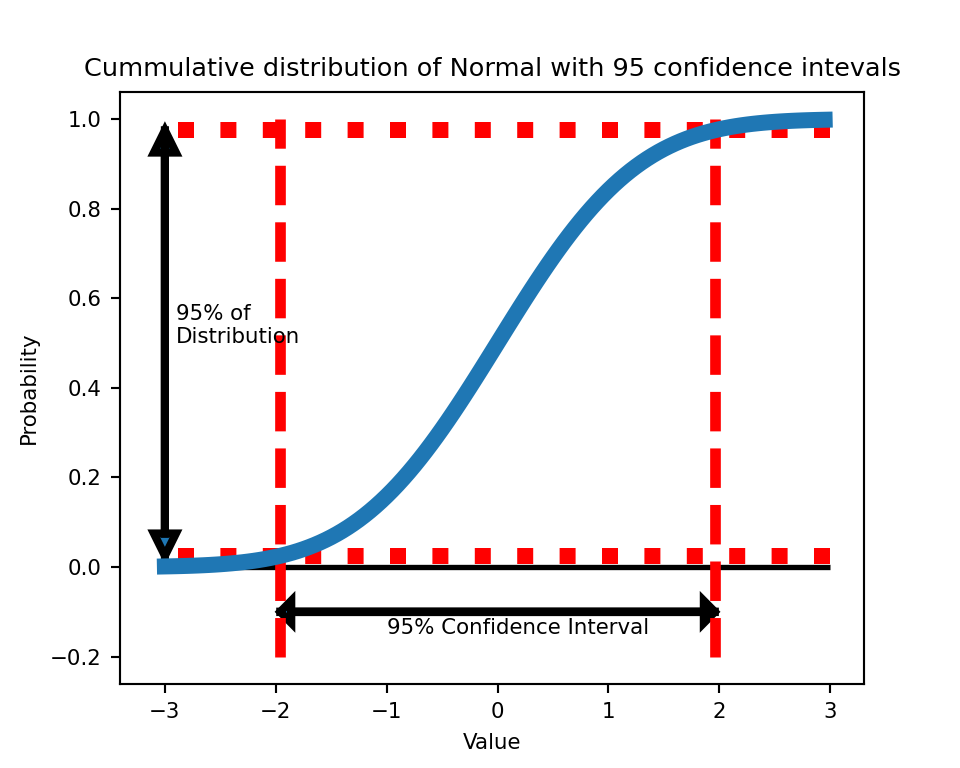

# Example, Inference for the mean

$$CI(mean) = CI(\bar{\mathbf{X}}) = MLE(\theta | \mathbf{X})\ \pm\ \frac{s}{\sqrt{n}} Z_\alpha$$

Where,  
- $Z_\alpha$ is the standard Normal distribution evaluated at confidence level, $\alpha$  
- standard error is given by $s/ \sqrt{n}$  
- $s$ is the standard deviation estimate  
- $n$ is the number of samples.

# Interpretation of Confidence Intervals

How can we interpret the confidence interval?

- Confidence intervals are with respect to the the sampling distribution of a statistic $s(\hat{\mathcal{F}})$
- Two-sided interval, $1 - 2 \alpha$, represent uncertainty in the sample statistic values computed from repeated samples of the population, $\hat{\mathcal{F}}_i$
- Confidence intervals do not indicate the probability $s(\hat{\mathcal{F}})$ is in a range

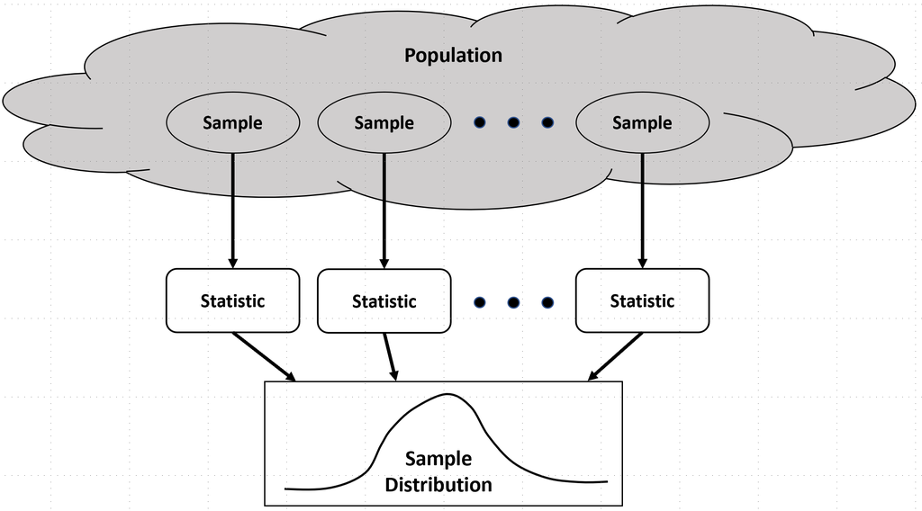

Sampling distribution of unknown population parameter

# Test of Hypothesis

- a **test of hypothesis** is made of two statements, each being an educated guess about the true value of the **parameter(s)** of one or several populations
- the **null hypothesis** $H_0$ usually says something “uninteresting” and they suggest a points toward some status quo, such as
  - the effect of this drug is not significantly than the control in reducing headaches
  - these two groups came from the same underlying distribution
- the **alternative hypotheses** $H_1$ is a competing statement that suggest something to the contrary and suggests some interesting **effect**, such as
  - a drug is significantly difference from a **control**
  - Yield of wheat is significantly different between two seed types
- There can be many alternative hypotheses
  - There is a significant difference in means
  - Difference in means is greater
  - Difference in means is less
  - Can be an infinite number; e.g. alternative distributions

# Examples of null and alternative hypotheses

| test | parameter | null hypothesis $H_0$ | alternative hypothesis $H_1$ (one-tailed) | alternative hypothesis $H_1$ (two-tailed) |
| --- | --- | --- | --- | --- |
| mean | $\mu$ | $\mu = c$ | $\mu < c$ (or $>$) | $\mu \ne c$ |
| variances | $\sigma_1, \sigma_2$ | $\sigma_1 = \sigma_2$ | $\sigma_1 < \sigma_2$ (or $>$) | $\sigma_1 \ne \sigma_2$ |
| distribution | $\mu, \sigma$ | $X \sim N(\mu, \sigma)$ | N/A | $X \not \sim N(\mu, \sigma)$ |
| correlation | $\rho$ | $\rho(X,Y) = 0$ | $\rho(X,Y) > 0$ | $\rho(X,Y) \ne 0$ |

# Hypothesis testing steps

The steps required to perform a formal two-sample hypothesis test

- State population assumptions of null hypothesis: $H_0$
- State alternative hypothesis: $H_a$
  - Typically stated in terms of a **treatment group** vs. **control group**
  - Treatment is the factor that differentiates the population
- Decide on a significance level (probability cutoff or **Type I error threshold**): e.g. 0.1, 0.05, and 0.01
- Data is collected for the different treatments
  - Treatment used for comparison is the **control**
- Compute the **test statistic** and evaluate based on the cutoff value

# Hypothesis testing steps

- Think of $H_0$ and $H_1$ as two assumptions *about the population* opposed to each other and competing for attention
- Under the assumption of $H_0$, we expect the statistic(s) we collect to follow a certain distribution (or some other condition)
3. Collect a sample of data (our **evidence**), compute the statistic(s) and probability to get the statistic(s) if $H_0$’s holds, or the **p-value**
4. Compare the p-value to the pre-determined threshold $\alpha$, or **type-I error** threshold, usually $\alpha = 0.01$ or $\alpha = 0.05$
5. If p-value $< \alpha$ we **reject $H_0$**, otherwise we **fail to reject $H_0$**
- We avoid saying that we “accept” $H_0$
- p-value $< \alpha$ does **not** mean we accept the alternative
- May be able tox conclude $H_a$ in certain cases

# Hypothesis testing steps

Test statistic used a a **decision rule**

- Only two possible outcomes
  - **Reject the null-hypothesis:** This is not the same as accepting the alternative hypothesis
  - **Fail to reject the null hypothesis:** This is not the same as accepting the null hypothesis
- Failing to rejecting the null hypothesis can occur for several reasons
  - The alternative hypothesis was false to begin with
  - There is not enough evidence for the **effect size**
- Roughly speaking, the effect size is the difference of the test statistic in populations under the different treatments

# the p-value

- P-value is the probability, under $H_0$, that we get a statistic **as extreme or more extreme** than the one we got
- **Extreme** depends on whether the test is **one-tailed** or **two-tailed**
- Derive the p-value by computing the **statistic(s)** and evaluate the quantile of the null distribution, $H_0$
- Low p-value means our evidence against $H_0$ is too strong to ignore
  - How strong it needs to be is controlled by our choice of $\alpha$
  - **Smaller $\alpha$** means we need **stronger evidence** to reject $H_0$; a more **conservative** test
- Together the p-value and the significance threshold $\alpha$ determine whether we reject or fail to reject $H_0$
  - The decision rule of the hypothesis test

# a simple test of hypothesis

- say we have a random variable $X$ that follows an unknown distribution
- $H_0: \mu = 23, \sigma = 10$
- $H_1: \mu \ne 23, \sigma = 10$ and we choose $\alpha = 0.05$
- we collect a sample of size $17$ and compute the sample mean $\bar x = 20.2$
- by the CLT we know that $\bar X \sim N(\mu, \frac{\sigma}{\sqrt n}) = N(23, 10/\sqrt{17})$
- we refer to $N(23, 10/\sqrt{17})$ and look up the probability of getting $\bar x = 20.2$ or something more extreme (farther away from 23 than 20.2 is, in either direction because the test is two-tailed)
- we can look up the p-value in Python by running `2*scipy.stats.norm.cdf(20.2, loc = 23, scale = 10/np.sqrt(17)) -> 0.25` (we multiply by two because the test is two-tailed), so we fail to reject $H_0$

# one-tailed test of hypothesis

- $H_0: \mu = \mu_0$ vs $H_a: \mu > \mu_0$
- if the statistic falls in the **critical (red) region**, we reject $H_0$ because p-value $< \alpha$ (top graph)
- if the statistic falls in the **blue region**, we fail to reject $H_0$ because p-value $> \alpha$ (bottom graph)

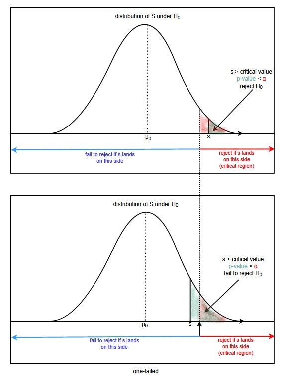

# two-tailed test of hypothesis

- $H_0: \mu = \mu_0$ vs $H_a: \mu \ne \mu_0$
- if the statistic falls in the **critical (red) region**, we reject $H_0$ because $2\times$p-value $< \alpha$ (top graph)
- if the statistic falls in the **blue region**, we fail to reject $H_0$ because $2\times$p-value $> \alpha$ (bottom graph)

[figure not shown]

# Student t-distribution

[**Student t-distribution**](https://en.wikipedia.org/wiki/Student%27s_t-distribution), or simply the t-distribution, is the distribution of the difference of means of two Normally distributed random variables

- One and two tailed hypothesis test of difference of means for Normally distributed random variables based on t-distribution - the **t-test** family
- t-distribution has one parameter, the **degrees of freedom**, denoted as $\nu$
- The PDF of the t-distribution is a rather complex looking result:

$$P(x\ |\ \nu) = \frac{\Gamma(\frac{\nu + 1}{2})}{\sqrt{\nu \pi} \Gamma(\frac{\nu}{2})} \bigg(1 + \frac{x^2}{\nu} \bigg)^{- \frac{\nu + 1}{2}}\\
where\\
\Gamma(x) = Gamma\ function$$

# Student t-distribution

[**Student t-distribution**](https://en.wikipedia.org/wiki/Student%27s_t-distribution), or simply the t-distribution, is the distribution of the difference of means of two Normally distributed random variables

- t-distribution has one parameter, the **degrees of freedom**, denoted as $\nu$

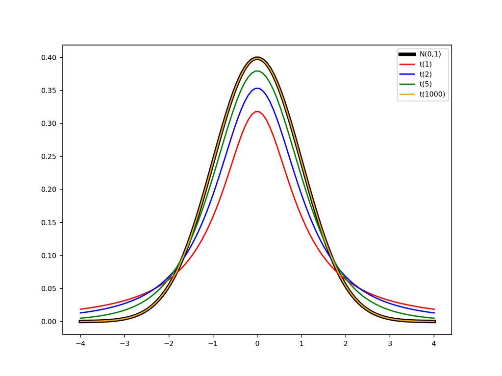

# Power of Tests

The **power of a test** is often neglected, leading to poor test results

- Power is formally defined as:

$$power = P(reject\ H_0| when\ H_a\ is\ true)$$

# Power of Tests

Consider the power for the two sample t-test for the difference of means which depends on:

- The type of test
- The number of samples
- The anticipated difference in the population means, or **effect size**
- The significance level of the test

# Power of Tests

When computing power, you can ask several questions

- Typically, determine how big a sample is required to have high probability of rejecting the null hypothesis given the expected effect size
  - Often, a power level of 0.8 is considered adequate
  - But, power level of 0.8 leaves a 1 in 5 chance of not detecting the desired effect
- Or, determine how big an effect is required for a fixed sample size to have hight probability of rejecting the null hypothesis
- Finally, determine the how different cutoff values change the probability of detecting an effect.

# Power of Tests

Example: power of t-test controlled by sample size, effect size and cut-off value

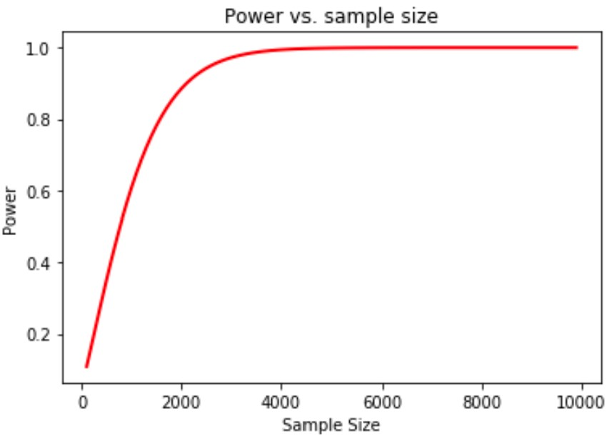

Power vs. sample size for t-test

# Power of Tests

Example: power of t-test controlled by sample size, effect size and cut-off value

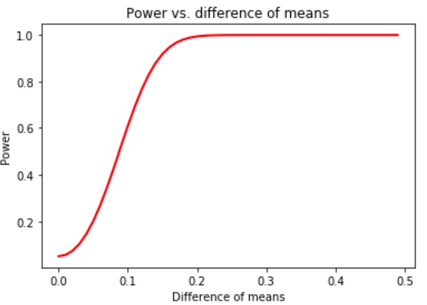

Power vs. effect size for t-test

# Power of Tests

Example: power of t-test controlled by sample size, effect size and cut-off value

- Hold sample size $=1000$ and effect size $= 0.1$ constant
- Determine cut-off limits, $\alpha$, or significance level:

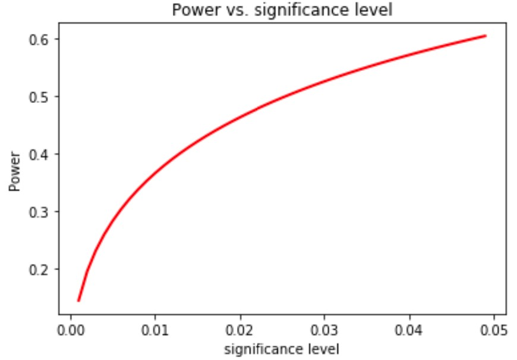

Power vs. significance level for t-test

# Hypothesis Tests on Counts

How can we perform an hypothesis test on count data?

- Pearson $\chi2$ (Chi-squared) test is an unpaired test for counts in different categories.
  - The null distribution is that there is no difference from the expected number of counts
  - Tests if counts of categories significantly different
  - These categories must be mutually exclusive. For example, does the patient have cancer?
- Examples of test on counts
  - Do the six categories of a die, (1,2,3,4,5,6), occur the same frequency (fair die)?
  - Do a group of tweets contain a specific word with unexpectedly high or low frequency?

# Pearson’s Chi-Squared Test

The difference in counts is $\chi^2$ distributed, giving the test its name

- The $\chi^2$ statistic depends on the **degrees of freedom** of the test
  - Degrees of freedom (DOF) are equal to n-1, with $n =$ the number of different categories

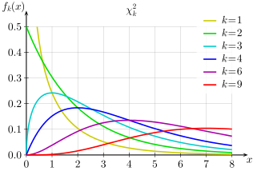

Chi-square distribution for different degrees of freedom

- Confidence intervals and p-values can be computed
- The $\chi$-squared distribution becomes flatter and with greater dispersion as the degrees of freedom increase
  - In practice, this means that you will need large samples to get a meaningful result if you have many categories

# Pearson’s Chi-Squared Test

How do we build a $\chi2$ test?

- $\chi^2$ test displayed as a Chi-squared table
- Test uses the sum of the differences of outcomes from expectations
  - Test if your sample has expected make up of counts from different categories
  - Example, if our population has equal numbers of men and women, then we can test if our sample is different from those expected probabilities.

# Building a Chi-squared table

A $\chi^2$ table typically has columns  
- The actual occurrence of events  
- The expected probability of these events; **distribution of the null hypothesis**  
- The expected occurrence of events given the expected probabilities under the null hypothesis - The difference between the occurrence and the expected number of events under the null hypothesis  
- The square of the difference  
- The sum of squared differences normalized by the expected number of occurrences; the $\chi2$ statistic.

```
##                  Action  occurrence expected_per expected_occurance   diff  \
## 0            Leave Page          55          0.6               72.0  -17.0
## 1     Continue Purchase          43          0.3               36.0    7.0
## 2  Add More to Purchase          22          0.1               12.0   10.0
## 3                Totals         120        [nan]              [nan]  [nan]
##
##   sqr_diff  diff_expect
## 0    289.0     4.013889
## 1     49.0     1.361111
## 2    100.0     8.333333
## 3    [nan]    13.708333
```

# ANOVA Theory

How can we perform comparisons between the multiple groups of data?

- Groups have each been subject to a different treatment is known as **one-way ANOVA**.
- General idea; determine if the groups within the data set all have the same variance
  - Did the different treatments lead to significantly different variances within the groups?
- The differences in variance is measured by the **F statistic**
  - F-statistic is defined by the ratio:

$$F = \frac{Variance\ between\ treatments}{Variance\ within\ treatments}$$

- F is close to 1.0 if the treatments exhibited no significant effect
- If the treatment has a significant effect on **at least one of the groups**, the F statistic will be $\gt 1$

# ANOVA Theory

F statistic, follows an F distribution.

- F distribution has two parameters which are the **degrees of freedom**
  - The between between treatments DOF
  - The within treatments DOF

$$\begin{align}
degrees\ of\ freedom\ between\ treatments\ &= DFT = I - 1 \\
degrees\ of\ freedom\ within\ treatments\ &= DFE = n - I
\end{align}$$

Where;

$$\begin{align}
I &= number\ of\ treatments\ or\ groups \\
n &= total\ number\ of\ subjects\ or\ samples
\end{align}$$

# ANOVA Theory

Two two DOF define the shape of the F distribution

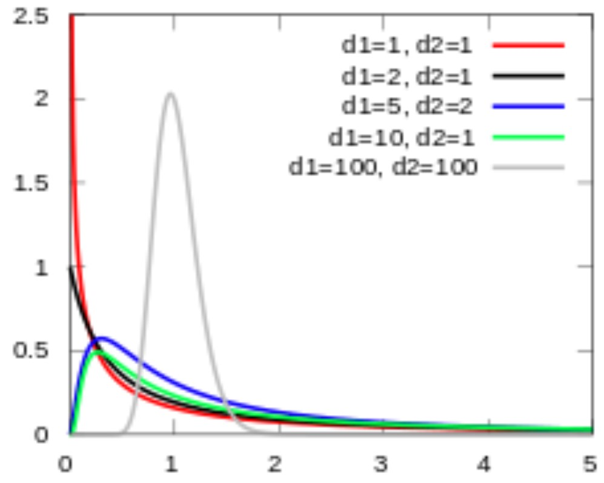

F distribution for different degrees of freedom

- The null distribution is that the treatments have had no significant effect
- The p-value is computed and compared to the cutoff value using the F distribution

# Tests on Distributions

Can we use make hypothesis tests on distribution assumptions?

- Yes, there are many hypothesis tests for distribution assumptions
- Be careful! Make sure you know which is the null hypothesis
  - Typically, the null hypothesis is the sample is the candidate distribution
  - Alternative hypothesis is some other distribution
  - Are an infinite number of alternative hypothesis

Examples:

- [Anderson Darling Test](https://docs.scipy.org/doc/scipy/reference/generated/scipy.stats.anderson.html): useful for many distributions
- [Shapiro Wilks Test](https://docs.scipy.org/doc/scipy/reference/generated/scipy.stats.shapiro.html): more powerful test for Normality
- [Kolmogorov-Smirnov Test](https://docs.scipy.org/doc/scipy/reference/generated/scipy.stats.kstest.html) a very general nonparametric test
  - Lower power than some other options
  - Our focus here

# Tests on Distributions

Focus on the Kolmogorov-Smirnov test

# The Kolmogorov-Smirno Statistic

Example: KS Statistic is the maximum distance between the CDF of two sets of samples

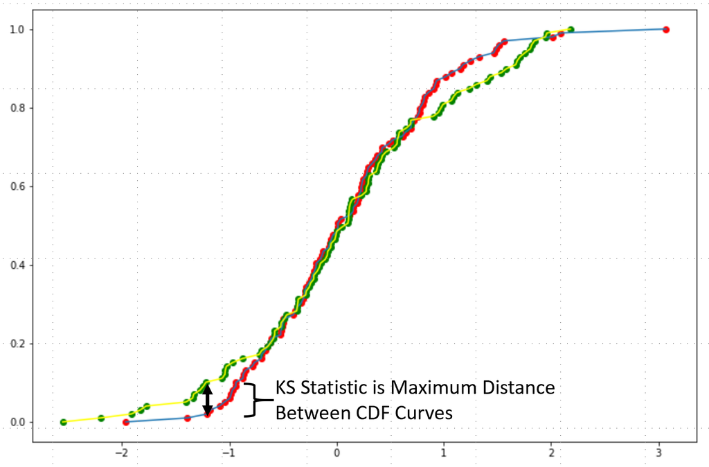

Illustration of the KS Statistic

# multiple hypotheses and p-value fishing

- recall that the statistic depends on the sample size: the larger the sample size, the more likely we are to reject $H_0$
- this means we can run a test of hypothesis and fail to reject $H_0$, then go back and collect more data and try again until we finally reject $H_0$: this is called **p-value fishing** and it is a form of cheating!
- the problem is that the **sample size** should be stated **prior to testing**, and changing it later is akin to “moving the goal posts”
- we can use **power analysis** to determine the appropriate **sample size** given the expected the expected **effect size**, or vice versa
- we compute power differently depending on the test

# multiple hypotheses

Testing multiple hypothises simultaiously is a slippery slope

- Example, what if we set the Type I error rate or signicicance level at $\alpha=0.05$
- Have about 1 in 20 chance of a **false positive**
- With just 20 variables there are ${n \choose k} = {20 \choose 2} = 190$ pair-wise comparison
- Expect about 9-10 false positives!

# P-Value mining

Common erroneous technique is to sample data until desired answer is reached

**See Example Notebook**

# Summary

Statistical inference seeks to characterize the uncertainty in estiamtes

- Statistics are estimates of population parameters
- Inferences using statistics must consider the uncertainty in the estimates
- Confidence intervals quantify uncertainty in statistical estimates
  - **Two-sided confidence intervals:** express confidence that a value is within some range around the point estimate
  - **One-sided confidence intervals:** express confidence that the point estimate is greater or less than some range of values

# [notebook time]

### we return to the lecture later